# Lab Week 03: Linear Regression - Part 2

Pouria

1/26/2022

# Lab Prompt

In this lab, we will study regression with 2 predictors, one continuous, and one qualitative, using the `Credit` data from the package `ISLR`.

1. Build a linear model of `Balance` as a function of `Student` status. Compare the results with that from a t-test. What do you conclude?
2. Now build a model with `Balance` as a function of `Income`. What do you conclude?
3. Next, we will build a model with both predictors, `Student` status and `Income`.

   3.a. Plot the data, using different markers for `Student` status

   3.b. Develop a model corresponding to Figure 3.7 (left). Plot the model with the data, as in 3.a. What do you conclude?

   3.c. Now develop and plot the full model corresponding to Figure 3.7 (right). Compare the result with those of an ANCOVA analysis. What do you conclude?

# Lab 1

Model `Balance` as a function of `Student`

```r
# Model Balance as a function of Student
```

[output not shown]

# Lab 1

Compare with t-test

```r
# Compare the results with those from a t-test
```

```
##               No
## Yes 1.487734e-07
```

# Lab 2

Model `Balance` as a function of `Income`

```r
# Model Balance as a function of Income
```

[output not shown]

# Lab 3(a)

Plot the data points

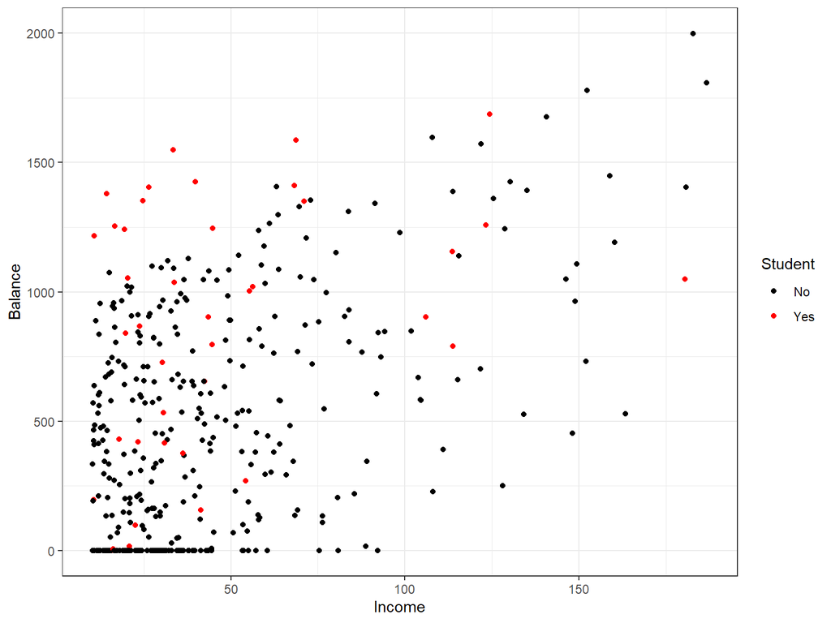

# Lab 3(b)

Model `Balance` as a function of both `Student` and `Income`

```r
# Model Balance as a function of Student and Income
```

[output not shown]

# Lab 3(b)

Or just simply use `Student` with no need for introducing a dummy variable.

# Lab 3(b)

Plot `Balance` as a function of `Student` and `Income` (Similar to Fig. 3.7(Left))

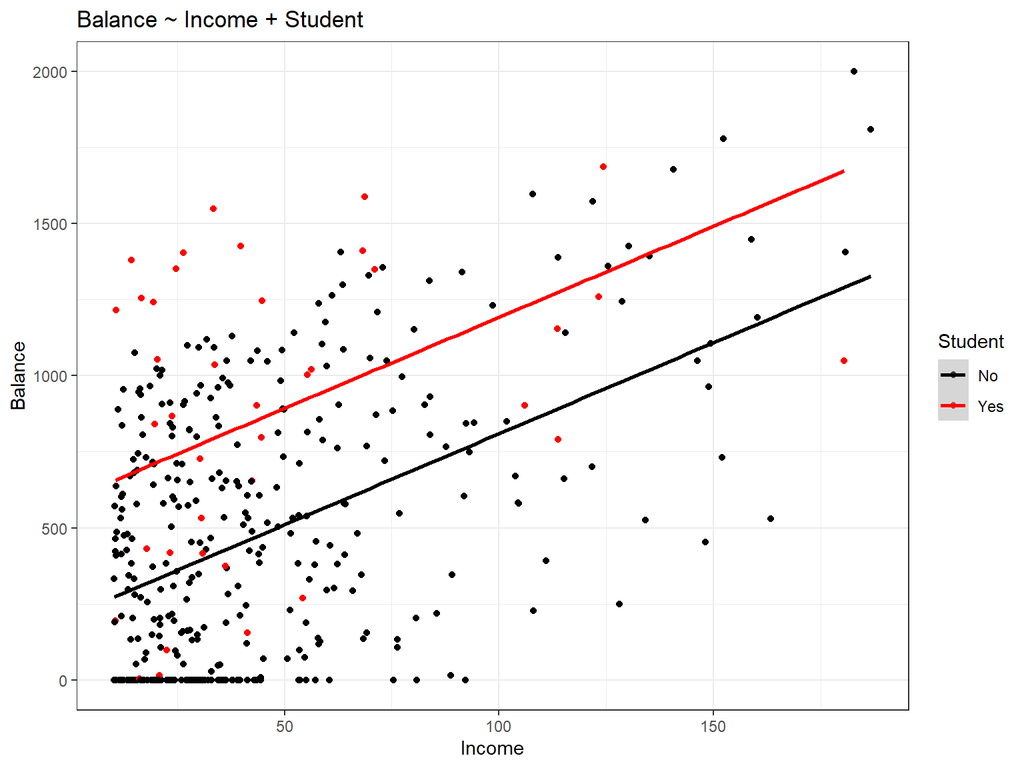

# Lab 3(c)

Model `Balance` as a function of both `Student`, `Income` and their interaction

```r
# Model Balance as a function of Student, Income and their interaction
```

[output not shown]

# Lab 3(c)

Compare with ANCOVA

```r
# Compare the results with those from ANCOVA
```

```
## [1]        NA 0.2488919
```

# Lab 3(c)

Plot the full model (Similar to 3.7(Right))

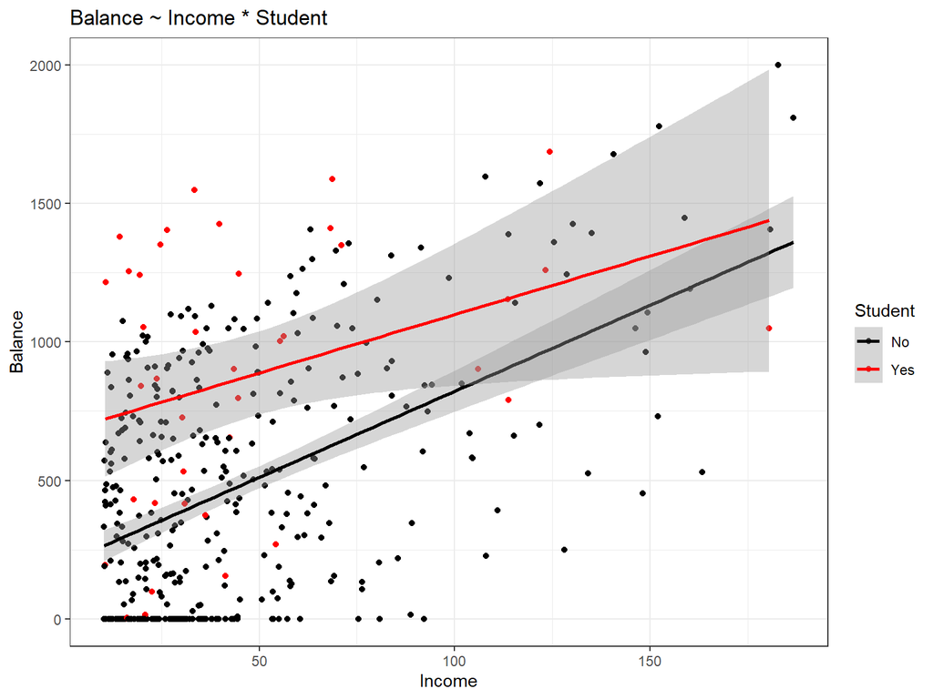